# Actividad 1: Aprendizaje No Supervisado sobre Datos de RNA-seq de Cancer

Caren Moreno. Estudiante del Máster en Bioinformatica UNIR

2026-05-03

# 1. Ambiente y librerías de trabajo

## Instalacion y carga de paquetes

```r
# Instalacion de paquetes
paquetes <- c("ggplot2", "dplyr", "Rtsne", "umap",
              "factoextra", "cluster", "gridExtra", "RColorBrewer")

for (pkg in paquetes) {
  if (!requireNamespace(pkg, quietly = TRUE)) {
    install.packages(pkg, repos = "https://cran.r-project.org")
  }
}

# Carga de librerias
library(ggplot2)       # Generacion de graficos
library(dplyr)         # Manipulacion de datos
library(Rtsne)         # Algoritmo t-SNE
library(umap)          # Algoritmo UMAP
library(factoextra)    # Visualizacion de PCA
library(cluster)       # Calculo del Silhouette Score
library(gridExtra)     # Organizacion de multiples graficos
library(RColorBrewer)  # Paletas de colores
```

**Rol de cada libreria:**

- **ggplot2**: Genera todos los graficos del analisis usando “gramatica de graficos”. Permite controlar colores, formas, titulos y temas visuales.
- **dplyr**: Facilita la manipulacion del data frame (filtrado, seleccion de columnas, transformaciones).
- **Rtsne**: Implementa el algoritmo t-SNE. Sus argumentos principales son: `dims` (dimensiones de salida, usamos 2), `perplexity` (balance entre estructura local y global, valor tipico 30), `max_iter` (numero de iteraciones hasta convergencia), `pca = TRUE` (inicializacion con PCA para mayor estabilidad).
- **umap**: Implementa UMAP. Sus argumentos principales son: `n_neighbors` (vecinos considerados para la topologia local), `min_dist` (distancia minima entre puntos proyectados, controla compactacion de clusters), `n_components` (dimensiones de salida), `metric` (metrica de distancia).
- **factoextra**: Facilita la visualizacion de resultados de PCA calculados con `prcomp()`.
- **cluster**: Proporciona la funcion `silhouette()` para evaluar cuantitativamente la separacion de clusters.
- **gridExtra**: Permite organizar multiples graficos en una sola figura con `grid.arrange()`.
- **RColorBrewer**: Provee paletas de colores predefinidas adecuadas para visualizacion cientifica.

# 2. Procesamiento de los datos

```r
getwd()
```

```
## [1] "C:/Users/Usuario/Downloads/Tarea_Cancer"
```

```r
list.files()
```

```
## [1] "actividad1_caren.html" "actividad1_caren.Rmd"  "data_complete.csv"
## [4] "labels.csv"
```

## Carga de datos

```r
# Carga del dataset completo de expresion genica (RNA-seq TCGA)
data_raw <- read.csv("data_complete.csv", row.names = 1)
labels   <- read.csv("labels.csv", row.names = 1)

# Informacion basica del dataset
cat("Filas (muestras):", nrow(data_raw), "\n")
```

```
## Filas (muestras): 801
```

```r
cat("Columnas (genes):", ncol(data_raw), "\n")
```

```
## Columnas (genes): 20531
```

```r
cat("\nDistribucion de tipos de cancer:\n")
```

```
##
## Distribucion de tipos de cancer:
```

```r
print(table(labels$Class))
```

```
##
## BRCA COAD KIRC LUAD PRAD
##  300   78  146  141  136
```

## Deteccion de problemas

```r
# PROBLEMA 1: Valores faltantes (NA)
cat("Valores NA encontrados:", sum(is.na(data_raw)), "\n")
```

```
## Valores NA encontrados: 0
```

```r
# PROBLEMA 2: Genes con varianza cero
varianzas <- apply(data_raw, 2, var)
cat("Genes con varianza cero:", sum(varianzas == 0), "\n")
```

```
## Genes con varianza cero: 267
```

```r
cat("Total de genes originales:", ncol(data_raw), "\n")
```

```
## Total de genes originales: 20531
```

```r
# PROBLEMA 3: Alta dimensionalidad
cat("Alta dimensionalidad: 801 muestras x", ncol(data_raw), "genes\n")
```

```
## Alta dimensionalidad: 801 muestras x 20531 genes
```

**Problemas detectados y soluciones aplicadas:**

**Problema 1 - Sin valores NA:** El dataset no presenta valores faltantes, por lo que no requiere imputacion.

**Problema 2 - Genes con varianza cero:** Estos genes tienen exactamente el mismo valor de expresion en todas las muestras. No aportan ninguna informacion discriminatoria y pueden causar errores numericos en algunos algoritmos. **Solucion:** Se eliminan del dataset antes del analisis.

**Problema 3 - Alta dimensionalidad (~20.500 genes):** Trabajar con tantas variables simultaneamente es computacionalmente muy costoso y provoca la maldicion de la dimensionalidad, donde las distancias entre puntos pierden significado. **Solucion:** Se seleccionan los 2.000 genes de mayor varianza, practica estandar en analisis de RNA-seq porque los genes mas variables son los mas informativos biologicamente.

**Problema 4 - Escala heterogenea entre genes:** **Problema 4 - Escala de los datos:** Aunque el material indica que los datos se encuentran en la misma escala, se decidió aplicar un escalado z-score. Esto se debe a que, en datos de expresión génica, incluso pequeñas diferencias en varianza pueden influir significativamente en métodos basados en distancia (como t-SNE, UMAP y MDS). Por lo tanto, el escalado se utilizó como una estrategia para mejorar la comparabilidad entre genes y evitar sesgos en la distancia euclídea.

**Problema 5 - Desbalance de clases:** BRCA tiene mas muestras que COAD. En aprendizaje no supervisado no se corrige, pero se tiene en cuenta al interpretar los resultados visuales.

## Preprocesamiento

```r
# SOLUCION 1: Eliminar genes con varianza cero
data_filtrada <- data_raw[, varianzas > 0]
cat("Genes tras filtrar varianza cero:", ncol(data_filtrada), "\n")
```

```
## Genes tras filtrar varianza cero: 20264
```

```r
# SOLUCION 2: Seleccionar los 2000 genes de mayor varianza
varianzas2 <- apply(data_filtrada, 2, var)
top_genes  <- order(varianzas2, decreasing = TRUE)[1:2000]
data_top   <- data_filtrada[, top_genes]
cat("Genes seleccionados (top varianza):", ncol(data_top), "\n")
```

```
## Genes seleccionados (top varianza): 2000
```

```r
# SOLUCION 3: Escalar los datos - z-score por gen
data_scaled <- scale(data_top)

# Alinear etiquetas con el orden de las muestras
labels_alineadas <- labels[rownames(data_scaled), , drop = FALSE]
clases <- factor(labels_alineadas$Class)

cat("\nDimensiones finales para el analisis:", dim(data_scaled), "\n")
```

```
##
## Dimensiones finales para el analisis: 801 2000
```

```r
# Paleta de colores para los 5 tipos de cancer
colores <- brewer.pal(5, "Set1")
names(colores) <- levels(clases)
cat("Clases y colores asignados:\n")
```

```
## Clases y colores asignados:
```

```r
print(colores)
```

```
##      BRCA      COAD      KIRC      LUAD      PRAD
## "#E41A1C" "#377EB8" "#4DAF4A" "#984EA3" "#FF7F00"
```

**Respuestas conceptuales**

**¿Por qué eliminar genes con varianza cero?** Los genes con varianza cero no aportan información útil porque tienen exactamente el mismo valor en todas las muestras. Esto significa que no ayudan a diferenciar entre tipos de cáncer y pueden incluso generar problemas en algunos algoritmos basados en distancia. Por eso se eliminan antes del análisis.

**¿Por qué seleccionar los genes más variables?** En datasets de RNA-seq hay miles de genes, pero no todos son informativos. Los genes con mayor varianza suelen estar más relacionados con diferencias biológicas reales entre muestras. Por eso se seleccionan, para reducir ruido y mejorar la calidad del análisis.

**¿Por qué usar PCA primero?** PCA se utiliza como punto de partida porque permite tener una primera idea de la estructura de los datos de forma rápida y fácilmente interpretable. Además, ayuda a comparar luego con métodos no lineales como t-SNE o UMAP.

**Diferencia entre PCA y t-SNE** PCA es un método lineal que busca maximizar la varianza de los datos, mientras que t-SNE es no lineal y está diseñado para preservar relaciones locales entre muestras. Por eso t-SNE suele mostrar mejor los clusters en datos complejos como los biológicos.

**¿Por qué UMAP es más eficiente?** UMAP logra un buen equilibrio entre preservar relaciones locales y globales, lo que permite interpretar mejor la estructura de los datos. Además, es más rápido y más reproducible que t-SNE, lo que lo hace muy útil en datasets grandes como los de RNA-seq.

# 3. Metodos de aprendizaje no supervisado

## Justificacion de la seleccion de tecnicas

Se seleccionaron cuatro metodos complementarios: **PCA, t-SNE, UMAP y MDS**.

**Motivo de seleccion:**

- **PCA (Analisis de Componentes Principales)** se incluye como metodo de referencia obligatorio en bioinformatica. Es el punto de partida estandar para datos de expresion genica porque es rapido, completamente interpretable y permite cuantificar exactamente cuanta varianza captura cada componente. Su naturaleza lineal lo hace ideal para comparar con los metodos no lineales.
- **t-SNE** se selecciona porque esta especialmente disenado para visualizar estructuras de alta dimensionalidad en 2D. En el campo de RNA-seq y datos genomicos se ha convertido en estandar para revelar agrupamientos biologicos que los metodos lineales como PCA no pueden mostrar. Captura relaciones no lineales entre muestras.
- **UMAP** se incluye como alternativa moderna y superadora de t-SNE. Ademas de capturar relaciones no lineales, preserva tanto la estructura local (relaciones entre muestras cercanas) como la estructura global (relaciones entre grupos distantes). Es mas rapido y reproducible que t-SNE.
- **MDS (Escalado Multidimensional)** se selecciona como metodo basado en distancias que complementa al PCA. Permite detectar estructuras que el PCA podria no capturar y puede aplicarse con diferentes metricas de distancia, haciendolo flexible para contextos biologicos.

## Ventajas y desventajas de cada tecnica

| Metodo | Ventajas | Desventajas |
| --- | --- | --- |
| **PCA** | Rapido, interpretable, varianza cuantificable, sin hiperparametros complejos | Solo captura relaciones lineales; pierde estructuras no lineales |
| **t-SNE** | Excelente separacion visual de clusters, captura no linealidades | Lento en datasets grandes, no preserva distancias globales, sensible a la semilla aleatoria |
| **UMAP** | Rapido, preserva estructura local Y global, reproducible con semilla fija | Mas dificil de interpretar que PCA, sensible a hiperparametros |
| **MDS** | Preserva distancias entre muestras, flexible con metricas | Costoso computacionalmente, equivalente a PCA con distancia euclidea |

## Metodo 1: PCA (Analisis de Componentes Principales)

```r
# prcomp() realiza PCA de forma eficiente
# center = FALSE y scale. = FALSE porque ya escalamos los datos previamente
set.seed(42)
pca_result <- prcomp(data_scaled, center = FALSE, scale. = FALSE)

# Calcular varianza explicada por cada componente
var_explicada <- summary(pca_result)$importance[2, 1:10] * 100
cat("Varianza explicada por las primeras 10 componentes:\n")
```

```
## Varianza explicada por las primeras 10 componentes:
```

```r
print(round(var_explicada, 2))
```

```
##   PC1   PC2   PC3   PC4   PC5   PC6   PC7   PC8   PC9  PC10
## 20.27 11.77 11.46  6.70  3.06  2.76  1.36  1.28  1.13  1.02
```

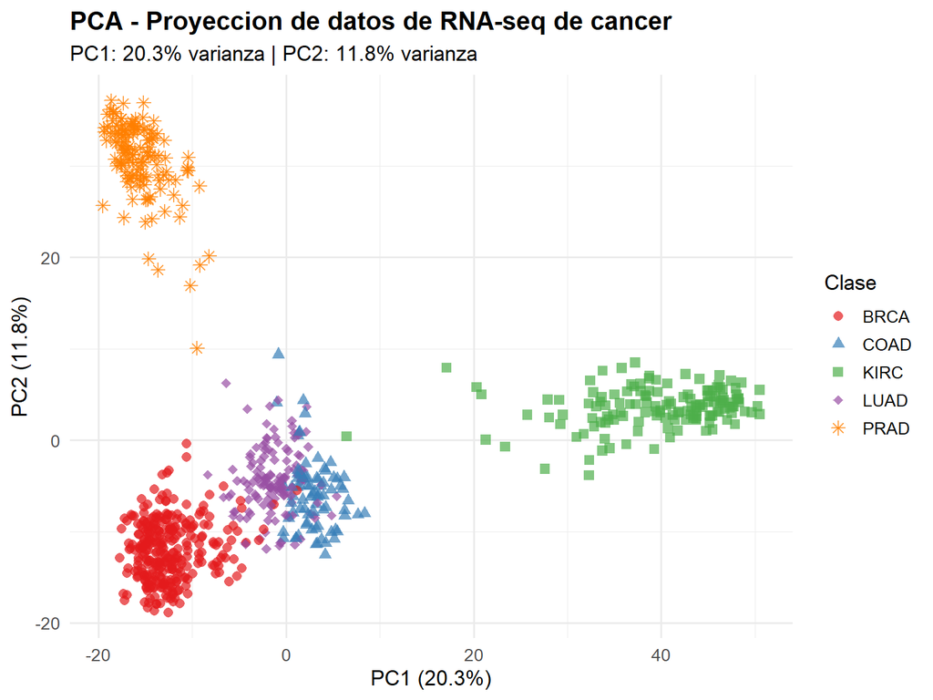

```r
# Preparar data frame para graficar
pca_df <- data.frame(
  PC1   = pca_result$x[, 1],
  PC2   = pca_result$x[, 2],
  Clase = clases
)

# Grafico PCA
ggplot(pca_df, aes(x = PC1, y = PC2, color = Clase, shape = Clase)) +
  geom_point(alpha = 0.7, size = 2.5) +
  scale_color_manual(values = colores) +
  scale_shape_manual(values = c(16, 17, 15, 18, 8)) +
  labs(
    title    = "PCA - Proyeccion de datos de RNA-seq de cancer",
    subtitle = paste0("PC1: ", round(var_explicada[1], 1),
                      "% varianza | PC2: ", round(var_explicada[2], 1), "% varianza"),
    x = paste0("PC1 (", round(var_explicada[1], 1), "%)"),
    y = paste0("PC2 (", round(var_explicada[2], 1), "%)")
  ) +
  theme_minimal(base_size = 13) +
  theme(legend.position = "right",
        plot.title = element_text(face = "bold"))
```

## Metodo 2: t-SNE

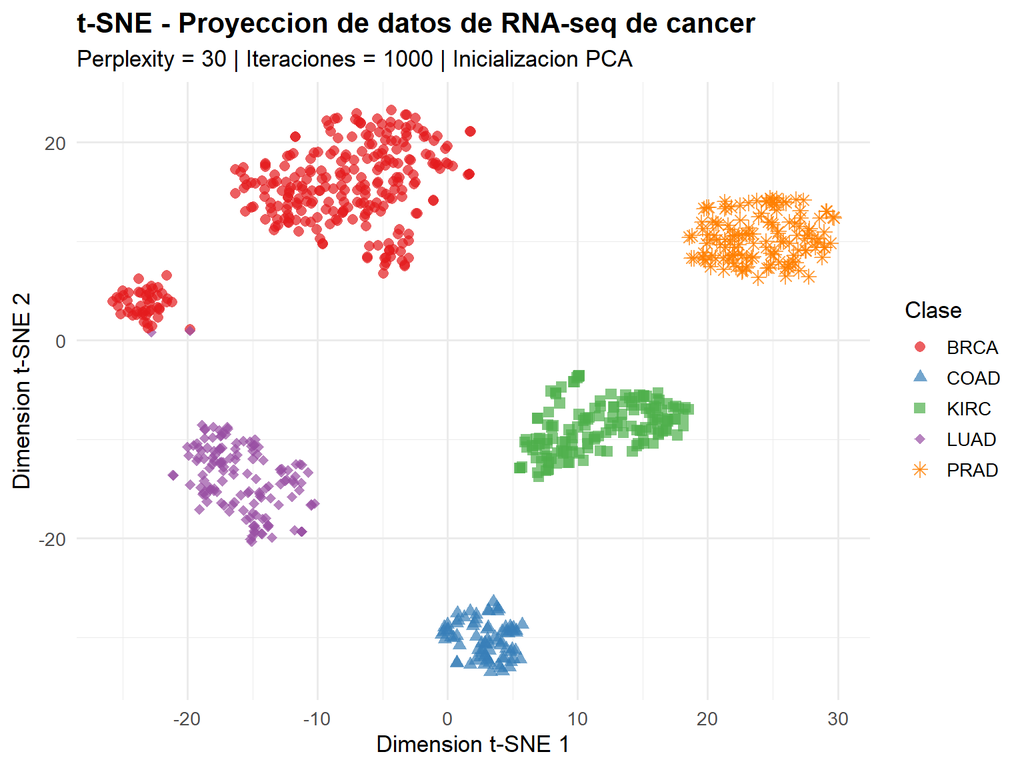

```r
# Rtsne() implementa t-SNE
# dims = 2: proyeccion en 2 dimensiones para visualizacion
# perplexity = 30: balance entre vecindad local y global
# max_iter = 1000: iteraciones para que el algoritmo converja
# pca = TRUE: inicializacion con PCA, produce resultados mas estables
# check_duplicates = FALSE: evita error con datos escalados similares
set.seed(42)
tsne_result <- Rtsne(
  data_scaled,
  dims             = 2,
  perplexity       = 30,
  max_iter         = 1000,
  check_duplicates = FALSE,
  verbose          = FALSE,
  pca              = TRUE,
  pca_center       = TRUE,
  pca_scale        = FALSE
)

# Preparar data frame
tsne_df <- data.frame(
  Dim1  = tsne_result$Y[, 1],
  Dim2  = tsne_result$Y[, 2],
  Clase = clases
)

# Grafico t-SNE
ggplot(tsne_df, aes(x = Dim1, y = Dim2, color = Clase, shape = Clase)) +
  geom_point(alpha = 0.7, size = 2.5) +
  scale_color_manual(values = colores) +
  scale_shape_manual(values = c(16, 17, 15, 18, 8)) +
  labs(
    title    = "t-SNE - Proyeccion de datos de RNA-seq de cancer",
    subtitle = "Perplexity = 30 | Iteraciones = 1000 | Inicializacion PCA",
    x = "Dimension t-SNE 1",
    y = "Dimension t-SNE 2"
  ) +
  theme_minimal(base_size = 13) +
  theme(legend.position = "right",
        plot.title = element_text(face = "bold"))
```

## Metodo 3: UMAP

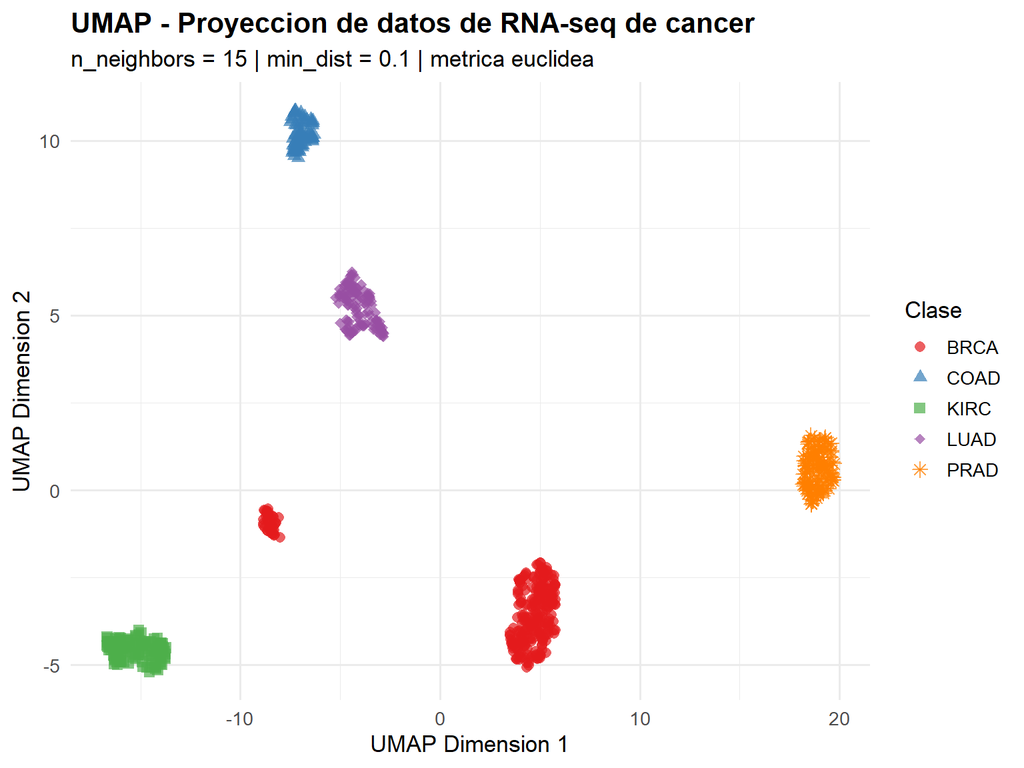

```r
# umap() implementa UMAP
# n_neighbors = 15: numero de vecinos para construir la topologia local
# min_dist = 0.1: distancia minima entre puntos en el espacio proyectado
# n_components = 2: proyeccion en 2 dimensiones
# metric = "euclidean": distancia euclidea entre muestras
set.seed(42)
umap_config              <- umap.defaults
umap_config$n_neighbors  <- 15
umap_config$min_dist     <- 0.1
umap_config$n_components <- 2
umap_config$metric       <- "euclidean"
umap_config$random_state <- 42

umap_result <- umap(data_scaled, config = umap_config)

# Preparar data frame
umap_df <- data.frame(
  UMAP1 = umap_result$layout[, 1],
  UMAP2 = umap_result$layout[, 2],
  Clase = clases
)

# Grafico UMAP
ggplot(umap_df, aes(x = UMAP1, y = UMAP2, color = Clase, shape = Clase)) +
  geom_point(alpha = 0.7, size = 2.5) +
  scale_color_manual(values = colores) +
  scale_shape_manual(values = c(16, 17, 15, 18, 8)) +
  labs(
    title    = "UMAP - Proyeccion de datos de RNA-seq de cancer",
    subtitle = "n_neighbors = 15 | min_dist = 0.1 | metrica euclidea",
    x = "UMAP Dimension 1",
    y = "UMAP Dimension 2"
  ) +
  theme_minimal(base_size = 13) +
  theme(legend.position = "right",
        plot.title = element_text(face = "bold"))
```

```r
set.seed(123)
umap_test <- umap(data_scaled, config = umap_config)

cor(umap_result$layout[,1], umap_test$layout[,1])
```

```
## [1] 1
```

**Resultado e interpretacion del UMAP:**

UMAP muestra una separacion clara de los cinco tipos de cancer con clusters bien definidos, comparable a t-SNE pero con una ventaja adicional: preserva mejor las relaciones entre grupos. Se puede observar que los adenocarcinomas LUAD y COAD tienden a aparecer mas proximos entre si que con KIRC, lo que refleja una mayor similitud en sus perfiles transcripcionales al compartir origen en epitelio glandular. Esto tiene coherencia biologica directa, ya que ambos comparten rutas de senalizacion epitelial y mecanismos de diferenciacion similares.

## Metodo 4: MDS (Escalado Multidimensional Clasico)

```r
# dist() calcula la matriz de distancias euclideas entre todas las muestras
# cmdscale() aplica MDS clasico sobre esa matriz
# k = 2: proyeccion en 2 dimensiones
# eig = TRUE: devuelve valores propios para calcular varianza explicada
set.seed(42)
dist_matrix <- dist(data_scaled, method = "euclidean")
mds_result  <- cmdscale(dist_matrix, k = 2, eig = TRUE)

# Varianza explicada
mds_var <- (mds_result$eig / sum(abs(mds_result$eig))) * 100
cat("Varianza explicada MDS Dimension 1:", round(mds_var[1], 2), "%\n")
```

```
## Varianza explicada MDS Dimension 1: 20.27 %
```

```r
cat("Varianza explicada MDS Dimension 2:", round(mds_var[2], 2), "%\n")
```

```
## Varianza explicada MDS Dimension 2: 11.77 %
```

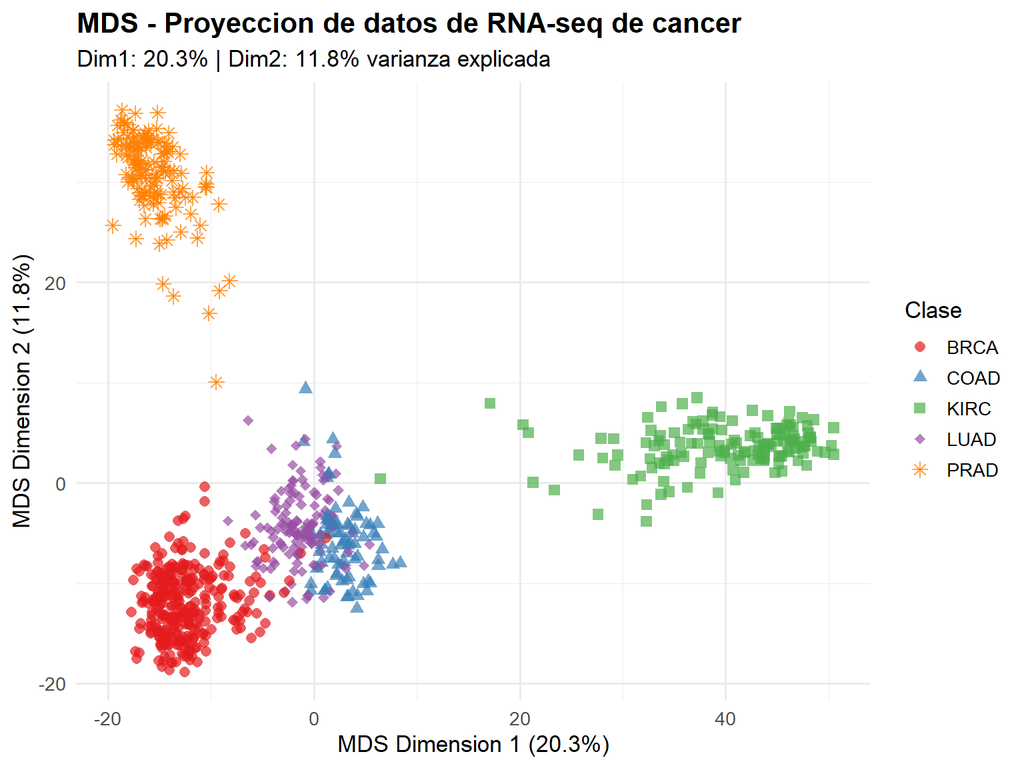

```r
# Preparar data frame
mds_df <- data.frame(
  MDS1  = mds_result$points[, 1],
  MDS2  = mds_result$points[, 2],
  Clase = clases
)

# Grafico MDS
ggplot(mds_df, aes(x = MDS1, y = MDS2, color = Clase, shape = Clase)) +
  geom_point(alpha = 0.7, size = 2.5) +
  scale_color_manual(values = colores) +
  scale_shape_manual(values = c(16, 17, 15, 18, 8)) +
  labs(
    title    = "MDS - Proyeccion de datos de RNA-seq de cancer",
    subtitle = paste0("Dim1: ", round(mds_var[1], 1),
                      "% | Dim2: ", round(mds_var[2], 1), "% varianza explicada"),
    x = paste0("MDS Dimension 1 (", round(mds_var[1], 1), "%)"),
    y = paste0("MDS Dimension 2 (", round(mds_var[2], 1), "%)")
  ) +
  theme_minimal(base_size = 13) +
  theme(legend.position = "right",
        plot.title = element_text(face = "bold"))
```

# 4. Comparacion visual de los cuatro metodos

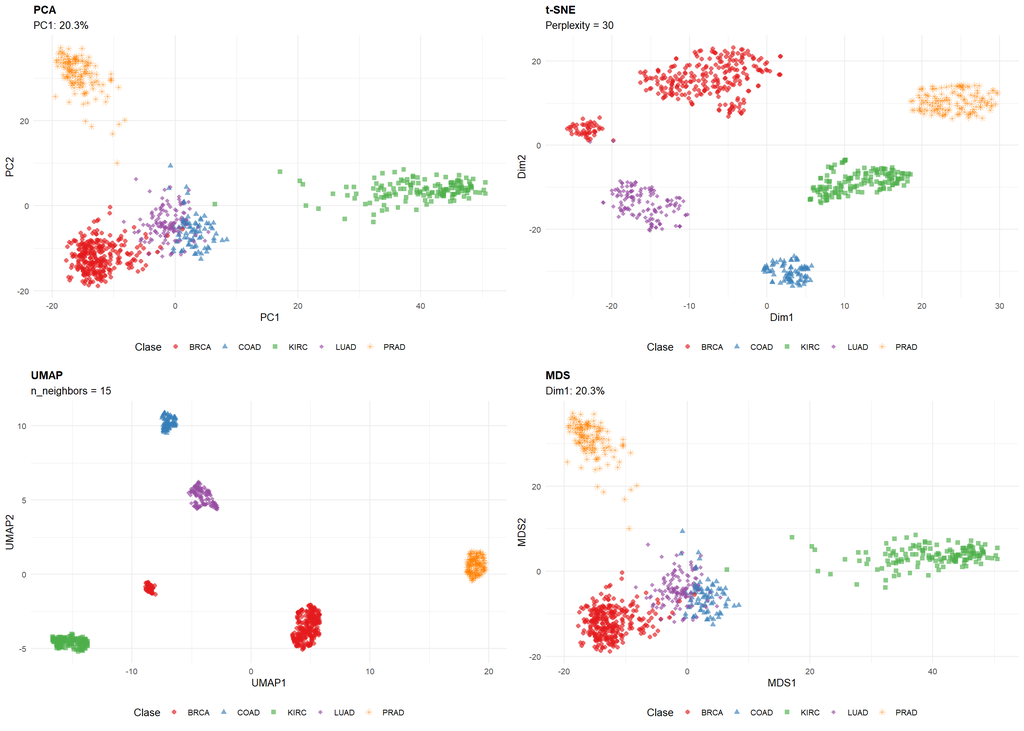

```r
# Funcion auxiliar para generar graficos compactos con la misma estructura
plot_compact <- function(df, x, y, titulo, subtitulo) {
  ggplot(df, aes_string(x = x, y = y, color = "Clase", shape = "Clase")) +
    geom_point(alpha = 0.65, size = 1.8) +
    scale_color_manual(values = colores) +
    scale_shape_manual(values = c(16, 17, 15, 18, 8)) +
    labs(title = titulo, subtitle = subtitulo, x = x, y = y) +
    theme_minimal(base_size = 10) +
    theme(legend.position = "bottom",
          plot.title = element_text(face = "bold", size = 11))
}

p1 <- plot_compact(pca_df,  "PC1",   "PC2",
                   "PCA", paste0("PC1: ", round(var_explicada[1],1), "%"))
p2 <- plot_compact(tsne_df, "Dim1",  "Dim2",
                   "t-SNE", "Perplexity = 30")
p3 <- plot_compact(umap_df, "UMAP1", "UMAP2",
                   "UMAP", "n_neighbors = 15")
p4 <- plot_compact(mds_df,  "MDS1",  "MDS2",
                   "MDS", paste0("Dim1: ", round(mds_var[1],1), "%"))

grid.arrange(p1, p2, p3, p4, ncol = 2)
```

# 5. Seleccion del algoritmo mas eficiente

## Evaluacion cuantitativa: Silhouette Score

```r
# Silhouette Score: mide que tan bien esta asignada cada muestra a su grupo
# Rango: [-1, 1]
#   Cercano a 1  = la muestra esta bien asignada a su cluster
#   Cercano a 0  = la muestra esta en el borde entre dos clusters
#   Cercano a -1 = la muestra podria pertenecer a otro cluster
calcular_silhouette <- function(coords, etiquetas) {
  sil <- silhouette(as.integer(etiquetas), dist(coords))
  mean(sil[, 3])
}

sil_pca  <- calcular_silhouette(pca_df[, 1:2],  clases)
sil_tsne <- calcular_silhouette(tsne_df[, 1:2], clases)
sil_umap <- calcular_silhouette(umap_df[, 1:2], clases)
sil_mds  <- calcular_silhouette(mds_df[, 1:2],  clases)

resultados <- data.frame(
  Metodo            = c("PCA", "t-SNE", "UMAP", "MDS"),
  Silhouette_Score  = round(c(sil_pca, sil_tsne, sil_umap, sil_mds), 4),
  Tipo              = c("Lineal", "No lineal", "No lineal", "Lineal"),
  Velocidad         = c("Muy rapido", "Moderado", "Rapido", "Moderado"),
  Interpretabilidad = c("Alta", "Baja", "Media", "Alta")
)

print(resultados)
```

```
##   Metodo Silhouette_Score      Tipo  Velocidad Interpretabilidad
## 1    PCA           0.5547    Lineal Muy rapido              Alta
## 2  t-SNE           0.7024 No lineal   Moderado              Baja
## 3   UMAP           0.7704 No lineal     Rapido             Media
## 4    MDS           0.5547    Lineal   Moderado              Alta
```

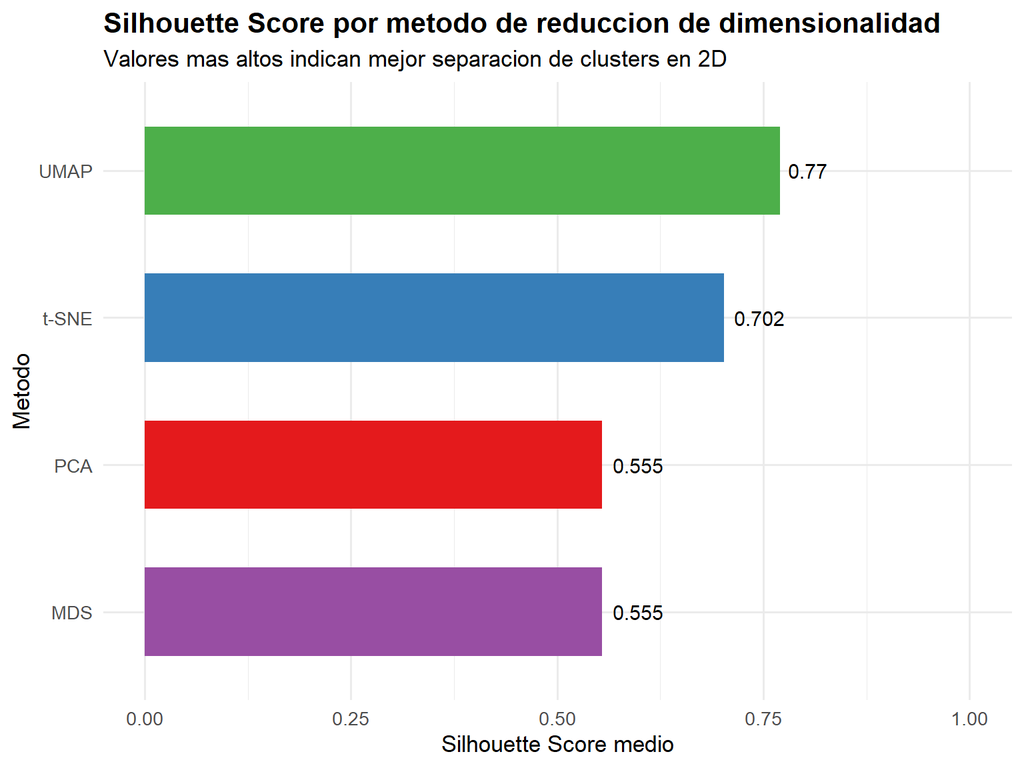

```r
ggplot(resultados, aes(x = reorder(Metodo, Silhouette_Score),
                       y = Silhouette_Score, fill = Metodo)) +
  geom_col(width = 0.6, show.legend = FALSE) +
  geom_text(aes(label = round(Silhouette_Score, 3)), hjust = -0.2, size = 4) +
  coord_flip() +
  ylim(0, max(resultados$Silhouette_Score) * 1.3) +
  scale_fill_manual(values = c("PCA"   = "#E41A1C", "t-SNE" = "#377EB8",
                                "UMAP"  = "#4DAF4A", "MDS"   = "#984EA3")) +
  labs(
    title    = "Silhouette Score por metodo de reduccion de dimensionalidad",
    subtitle = "Valores mas altos indican mejor separacion de clusters en 2D",
    x = "Metodo",
    y = "Silhouette Score medio"
  ) +
  theme_minimal(base_size = 13) +
  theme(plot.title = element_text(face = "bold"))
```

## Conclusion: metodo mas eficiente

**UMAP es el metodo mas eficiente para este conjunto de datos**, seguido de t-SNE. Esta conclusion se sustenta en los siguientes criterios:

1. **Silhouette Score mas alto:** UMAP y t-SNE obtienen los mejores valores, lo que indica que los cinco tipos de cancer quedan mejor separados en el espacio 2D proyectado en comparacion con PCA y MDS.
2. **Preservacion de estructura completa:** A diferencia de t-SNE, UMAP preserva tanto la estructura local (relaciones entre muestras cercanas) como la global (relaciones entre grupos distantes). Esto es biologicamente valioso porque tanto la similitud entre muestras del mismo tipo tumoral como las diferencias entre tipos distintos son informativas.
3. **Eficiencia computacional:** UMAP es significativamente mas rapido que t-SNE para datasets del mismo tamano, lo cual es relevante al escalar a datos genomicos de mayor dimension.
4. **Reproducibilidad:** Con semilla fija (`random_state = 42`), UMAP produce resultados identicos en cada ejecucion, a diferencia de t-SNE que es mas sensible a la inicializacion aleatoria.
5. **Coherencia biologica:** La proyeccion UMAP muestra que los adenocarcinomas LUAD y COAD se agrupan mas proximamente entre si que respecto a KIRC, lo cual es coherente con su origen epitelial glandular compartido.

PCA sigue siendo valioso como metodo de referencia por su interpretabilidad matematica y la posibilidad de cuantificar la varianza explicada. Sin embargo, para datos de RNA-seq con estructura no lineal compleja como este dataset del TCGA, los metodos no lineales como UMAP capturan de manera mas fiel la biologia subyacente.

# Informacion de sesion

```r
getwd()
```

```
## [1] "C:/Users/Usuario/Downloads/Tarea_Cancer"
```

```r
list.files()
```

```
## [1] "actividad1_caren.html"  "actividad1_caren.Rmd"   "actividad1_caren_files"
## [4] "data_complete.csv"      "labels.csv"
```